# Projets tutorés 2 | Devoir 3

YAHIA Mohammed Rafik | Denis MIANBE | Nihel BEDJOAUI | Lamya DAOUIRI

2023-05-17

# 1 Introduction

The dataframes needed for the baseline algorithm are already created previously :

- TableAgg from Devoir 1 for patients with baseline measurements.
- TableSuc from Devoir 2 for patients that met success criteria.

What is needed is merging them into one dataframe and preprocessing it to apply different ML models for our treatement results prediction.

# 2 Objective 01 : Importing the dataframes and merging them.

Importing the necessary libraries

```r
require(tidyverse)
require(caret)
require(caretEnsemble)
require(missForest)
require(doParallel)
require(explore)
require(plyr)
require(janitor)
require(lfactors)
require(magrittr)
require(skimr)
require(tibble)
require(stringr)
require(kableExtra)
require(prettydoc)
require(rmdformats)
```

Importing the dataframes from Devoir 1 and Devoir 2

```r
### DM Table with variable that indicates the ARM. LB Table that indicates drug results and day.
dm <- read.csv("ascii-data-files nida-ctn-0001-20230318/dm.csv", header = T, dec = ".")
dm2 <- read.csv("ascii-data-files nida-ctn-0002-20230318/dm.csv", header = T, dec = ".")
lb <- read.csv("ascii-data-files nida-ctn-0001-20230318/lb.csv", header = T, dec = ".")
lb2 <- read.csv("ascii-data-files nida-ctn-0002-20230318/lb.csv", header = T, dec = ".")

#Criteria of success D13 or D14 with negative opoids results.
# Importing lb database containg opioid test results, and dm with arm.
dm3 <- dm %>% filter(ARM %in% c("CLONIDINE","BUPRENORPHINE/NALOXONE")) %>% select(USUBJID, ARM)
dm4 <- dm2 %>% filter(ARM %in% c("CLONIDINE","BUPRENORPHINE/NALOXONE")) %>% select (USUBJID, ARM)
lb3 <- lb %>% filter(EPOCH == "ACTIVE", VISITNUM %in% c(1:14)) #Missing 5 patients from lb3 compared to dm3 when applying this filter. as they are still in screening epoch but have already been assigned in dm database "01_018076" "01_027452" "01_058918" "01_063935" "01_067193".
lb4 <- lb2 %>% filter(EPOCH == "ACTIVE", VISITNUM %in% c(1:14)) #Missing 27 patients from lb4 compared to dm4 when applying this filter.

# Adding the ARM column.
list_df10 = list(lb3, dm3)
tabURINE <- list_df10 %>%
  reduce(full_join, by='USUBJID') %>%
  select("USUBJID", "LBTEST", "LBORRES", "LBSTAT", "LBREASND", "LBSPEC", "LBMETHOD", "VISIT", "VISITNUM", "LBDY", "LBDTC", "ARM") #113 patients

list_df11 = list(lb4, dm4)
tabURINE2 <- list_df11 %>%
  reduce(full_join, by='USUBJID') %>%
  select("USUBJID", "LBTEST", "LBORRES", "LBSTAT", "LBREASND", "LBSPEC", "LBMETHOD", "VISIT", "VISITNUM", "LBDY", "LBDTC", "ARM") #231 patients

# Merging both tables
TableURINE <- rbind(tabURINE, tabURINE2)

# Success criteria met for these patients with NEGATIVE test results, others are a Failure.
TableSuc <- TableURINE %>%
  filter(VISITNUM %in% c(13,14) ) %>%
  filter(LBTEST == "OPIATE") %>%
  filter(LBORRES == "NEGATIVE") %>%
  mutate(PROTOCOLE = if_else(str_detect(USUBJID, "^01"), "In-patient protocol", "Out-patient protocol")) %>%
  mutate(PROTOCOLE = as.factor(PROTOCOLE)) %>%
  filter(ARM %in% c("CLONIDINE","BUPRENORPHINE/NALOXONE")) %>%
  # Issue with patient 02_036130. Filtered again because after join there was one patient that had SCREEN FAILURE on DM4 but got to the final table through LB4 because he had active epoch tests, which doesn't make sense.
  arrange(VISITNUM) %>%
  select(USUBJID, LBORRES)

# TableAgg from Devoir 1, for more information please refer to Devoir 1.
dm <- read.csv("ascii-data-files nida-ctn-0001-20230318/dm.csv", header = T, dec = ".")
tabDM <- dm %>% select(USUBJID, ARM, AGE, SEX)
vs <- read.csv("ascii-data-files nida-ctn-0001-20230318/vs.csv", header = T, dec = ".")
tabTEMP <- vs %>% filter(EPOCH=="SCREENING", VSTESTCD=="TEMP") %>% select(USUBJID, VSORRES)
tabTEMP <- distinct(tabTEMP)
colnames(tabTEMP) <- c("USUBJID", "TEMP")
tabRESP <- vs %>% filter(EPOCH=="SCREENING", VSTESTCD=="RESP") %>% select(USUBJID, VSORRES)
tabRESP <- distinct(tabRESP)
colnames(tabRESP) <- c("USUBJID", "RESP")
tabPULSEsitting <- vs %>% filter(EPOCH=="SCREENING", VSPOS=="SITTING", VSTESTCD=="PULSE") %>% select(USUBJID, VSORRES)
tabPULSEsitting <- distinct(tabPULSEsitting)
colnames(tabPULSEsitting) <- c("USUBJID", "PULSEsitting")
tabPULSEstanding <- vs %>% filter(EPOCH=="SCREENING", VSPOS=="STANDING", VSTESTCD=="PULSE") %>% select(USUBJID, VSORRES)
tabPULSEstanding <- distinct(tabPULSEstanding)
colnames(tabPULSEstanding) <- c("USUBJID", "PULSEstanding")
tabSBPsitting <- vs %>% filter(EPOCH=="SCREENING", VSPOS=="SITTING", VSTESTCD=="SBP") %>% select(USUBJID, VSORRES)
tabSBPsitting <- distinct(tabSBPsitting)
colnames(tabSBPsitting) <- c("USUBJID", "SBPsitting")
tabSBPstanding <- vs %>% filter(EPOCH=="SCREENING", VSPOS=="STANDING", VSTESTCD=="SBP") %>% select(USUBJID, VSORRES)
tabSBPstanding <- distinct(tabSBPstanding)
colnames(tabSBPstanding) <- c("USUBJID", "SBPstanding")
tabDBPsitting <- vs %>% filter(EPOCH=="SCREENING", VSPOS=="SITTING", VSTESTCD=="DBP") %>% select(USUBJID, VSORRES)
tabDBPsitting <- distinct(tabDBPsitting)
colnames(tabDBPsitting) <- c("USUBJID", "DBPsitting")
tabDBPstanding <- vs %>% filter(EPOCH=="SCREENING", VSPOS=="STANDING", VSTESTCD=="DBP") %>% select(USUBJID, VSORRES)
tabDBPstanding <- distinct(tabDBPstanding)
colnames(tabDBPstanding) <- c("USUBJID", "DBPstanding")
tabHEIGHT <- vs %>% filter(EPOCH=="SCREENING", VSTESTCD=="HEIGHT") %>% select(USUBJID, VSORRES)
tabHEIGHT <- distinct(tabHEIGHT)
colnames(tabHEIGHT) <- c("USUBJID", "HEIGHT")
tabWEIGHT <- vs %>% filter(EPOCH=="SCREENING", VSTESTCD=="WEIGHT") %>% select(USUBJID, VSORRES)
tabWEIGHT <- distinct(tabWEIGHT)
colnames(tabWEIGHT) <- c("USUBJID", "WEIGHT")
calculate_bmi <- function(dataframe, height_col, weight_col, bmi_col) {
  height_meters <- dataframe[[height_col]] * 0.0254
  weight_kg <- dataframe[[weight_col]] * 0.453592
  bmi <- weight_kg / (height_meters^2)
  dataframe[[bmi_col]] <- bmi
  return(dataframe)
}
tabBMI <- left_join(tabHEIGHT, tabWEIGHT, by="USUBJID")
tabBMI <- calculate_bmi(tabBMI, "HEIGHT", "WEIGHT", "BMI") %>% select("USUBJID", "BMI")
list_df1 = list(tabBMI, tabDBPsitting, tabSBPsitting, tabDBPstanding, tabSBPstanding, tabPULSEsitting, tabPULSEstanding, tabRESP, tabTEMP)
tabVS <- list_df1 %>% reduce(full_join, by='USUBJID')
sc <- read.csv("ascii-data-files nida-ctn-0001-20230318/sc.csv", header = T, dec = ".")
tabMARITAL <- sc %>% filter(SCTESTCD=="MARITAL") %>% select(USUBJID, SCORRES)
tabMARITAL <- distinct(tabMARITAL)
colnames(tabMARITAL) <- c("USUBJID", "MARITAL")
tabEDUC <- sc %>% filter(SCTESTCD=="EDUCYRS") %>% select(USUBJID, SCORRES)
tabEDUC <- distinct(tabEDUC)
colnames(tabEDUC) <- c("USUBJID", "EDUCYRS")
tabEMPLOY30 <- sc %>% filter(SCTESTCD=="EMPLOY30") %>% select(USUBJID, SCORRES)
tabEMPLOY30 <- distinct(tabEMPLOY30)
colnames(tabEMPLOY30) <- c("USUBJID", "EMPLOY30")
tabEMPLOY3Y <- sc %>% filter(SCTESTCD=="EMPLOY3Y") %>% select(USUBJID, SCORRES)
tabEMPLOY3Y <- distinct(tabEMPLOY3Y)
colnames(tabEMPLOY3Y) <- c("USUBJID", "EMPLOY3Y")
tabEMPLOY <- left_join(tabEMPLOY30, tabEMPLOY3Y, by="USUBJID")
list_df2 = list(tabEDUC, tabEMPLOY, tabMARITAL)
tabSC <- list_df2 %>% reduce(full_join, by='USUBJID')
lb <- read.csv("ascii-data-files nida-ctn-0001-20230318/lb.csv", header = T, dec = ".")
tabMETHADONE <- lb %>% filter(EPOCH=="SCREENING", LBTESTCD=="METHADON", LBMETHOD=="CENTRAL LAB") %>% select(USUBJID, LBORRES)
tabMETHADONE <- distinct(tabMETHADONE)
colnames(tabMETHADONE) <- c("USUBJID", "METHADONE")
tabMORPHINE <- lb %>% filter(EPOCH=="SCREENING", LBTESTCD=="MORPHINE") %>% select(USUBJID, LBORRES)
tabMORPHINE <- distinct(tabMORPHINE)
colnames(tabMORPHINE) <- c("USUBJID", "MORPHINE")
list_df3 = list(tabMETHADONE, tabMORPHINE)
tabLB <- list_df3 %>% reduce(full_join, by='USUBJID')
qs <- read.csv("ascii-data-files nida-ctn-0001-20230318/qs.csv", header = T, dec = ".")
tabQS <- qs %>% filter(EPOCH=="SCREENING", QSTESTCD=="VAS001") %>% select(USUBJID, QSORRES)
tabQS <- distinct(tabQS)
colnames(tabQS) <- c("USUBJID", "VAS001")
list_df4 = list(tabDM, tabSC, tabVS, tabQS, tabLB)
tabALL_01 <- list_df4 %>% reduce(full_join, by='USUBJID')
dm2 <- read.csv("ascii-data-files nida-ctn-0002-20230318/dm.csv", header = T, dec = ".")
tabDM2 <- dm2 %>% select(USUBJID, ARM, AGE, SEX)
vs2 <- read.csv("ascii-data-files nida-ctn-0002-20230318/vs.csv", header = T, dec = ".")
tabTEMP2 <- vs2 %>% filter(EPOCH=="SCREENING", VSTESTCD=="TEMP") %>% select(USUBJID, VSORRES)
tabTEMP2 <- distinct(tabTEMP2)
colnames(tabTEMP2) <- c("USUBJID", "TEMP")
tabTEMP2$TEMP[tabTEMP2$TEMP == 999.9] <- 99.9
tabRESP2 <- vs2 %>% filter(EPOCH=="SCREENING", VSTESTCD=="RESP") %>% select(USUBJID, VSORRES)
tabRESP2 <- distinct(tabRESP2)
colnames(tabRESP2) <- c("USUBJID", "RESP")
tabPULSEsitting2 <- vs2 %>% filter(EPOCH=="SCREENING", VSPOS=="SITTING", VSTESTCD=="PULSE") %>% select(USUBJID, VSORRES)
tabPULSEsitting2 <- distinct(tabPULSEsitting2)
colnames(tabPULSEsitting2) <- c("USUBJID", "PULSEsitting")
tabPULSEstanding2 <- vs2 %>% filter(EPOCH=="SCREENING", VSPOS=="STANDING", VSTESTCD=="PULSE") %>% select(USUBJID, VSORRES)
tabPULSEstanding2 <- distinct(tabPULSEstanding2)
colnames(tabPULSEstanding2) <- c("USUBJID", "PULSEstanding")
tabSBPsitting2 <- vs2 %>% filter(EPOCH=="SCREENING", VSPOS=="SITTING", VSTESTCD=="SBP") %>% select(USUBJID, VSORRES)
tabSBPsitting2 <- distinct(tabSBPsitting2)
colnames(tabSBPsitting2) <- c("USUBJID", "SBPsitting")
tabSBPstanding2 <- vs2 %>% filter(EPOCH=="SCREENING", VSPOS=="STANDING", VSTESTCD=="SBP") %>% select(USUBJID, VSORRES)
tabSBPstanding2 <- distinct(tabSBPstanding2)
colnames(tabSBPstanding2) <- c("USUBJID", "SBPstanding")
tabDBPsitting2 <- vs2 %>% filter(EPOCH=="SCREENING", VSPOS=="SITTING", VSTESTCD=="DBP") %>% select(USUBJID, VSORRES)
tabDBPsitting2 <- distinct(tabDBPsitting2)
colnames(tabDBPsitting2) <- c("USUBJID", "DBPsitting")
tabDBPstanding2 <- vs2 %>% filter(EPOCH=="SCREENING", VSPOS=="STANDING", VSTESTCD=="DBP") %>% select(USUBJID, VSORRES)
tabDBPstanding2 <- distinct(tabDBPstanding2)
colnames(tabDBPstanding2) <- c("USUBJID", "DBPstanding")
tabHEIGHT <- vs2 %>% filter(EPOCH=="SCREENING", VSTESTCD=="HEIGHT") %>% select(USUBJID, VSORRES)
tabHEIGHT <- distinct(tabHEIGHT)
colnames(tabHEIGHT) <- c("USUBJID", "HEIGHT")
tabWEIGHT <- vs2 %>% filter(EPOCH=="SCREENING", VSTESTCD=="WEIGHT") %>% select(USUBJID, VSORRES)
tabWEIGHT <- distinct(tabWEIGHT)
colnames(tabWEIGHT) <- c("USUBJID", "WEIGHT")
tabHEIGHT2 <- vs2 %>% filter(EPOCH=="SCREENING", VSTESTCD=="HEIGHT") %>% select(USUBJID, VSORRES)
tabHEIGHT2 <- distinct(tabHEIGHT2)
colnames(tabHEIGHT2) <- c("USUBJID", "HEIGHT")
tabHEIGHT2$HEIGHT[tabHEIGHT2$HEIGHT == 715] <- 71
tabWEIGHT2 <- vs2 %>% filter(EPOCH=="SCREENING", VSTESTCD=="WEIGHT") %>% select(USUBJID, VSORRES)
tabWEIGHT2 <- distinct(tabWEIGHT2)
colnames(tabWEIGHT2) <- c("USUBJID", "WEIGHT")
calculate_bmi <- function(dataframe, height_col, weight_col, bmi_col) {
  height_meters <- dataframe[[height_col]] * 0.0254
  weight_kg <- dataframe[[weight_col]] * 0.453592
  bmi <- weight_kg / (height_meters^2)
  dataframe[[bmi_col]] <- bmi
  return(dataframe)
}
tabBMI2 <- left_join(tabHEIGHT2, tabWEIGHT2, by="USUBJID")
tabBMI2 <- calculate_bmi(tabBMI2, "HEIGHT", "WEIGHT", "BMI") %>% select("USUBJID", "BMI")
list_df5 = list(tabBMI2, tabDBPstanding2, tabSBPstanding2, tabDBPsitting2, tabSBPsitting2, tabPULSEstanding2, tabPULSEsitting2, tabRESP2, tabTEMP2)
tabVS2 <- list_df5 %>% reduce(full_join, by='USUBJID')
sc2 <- read.csv("ascii-data-files nida-ctn-0002-20230318/sc.csv", header = T, dec = ".")
tabMARITAL2 <- sc2 %>% filter(SCTESTCD=="MARITAL") %>% select(USUBJID, SCORRES)
tabMARITAL2 <- distinct(tabMARITAL2)
colnames(tabMARITAL2) <- c("USUBJID", "MARITAL")
tabEDUC2 <- sc2 %>% filter(SCTESTCD=="EDUCYRS") %>% select(USUBJID, SCORRES)
tabEDUC2 <- distinct(tabEDUC2)
colnames(tabEDUC2) <- c("USUBJID", "EDUCYRS")
tabEMPLOY302 <- sc2 %>% filter(SCTESTCD=="EMPLOY30") %>% select(USUBJID, SCORRES)
tabEMPLOY302 <- distinct(tabEMPLOY302)
colnames(tabEMPLOY302) <- c("USUBJID", "EMPLOY30")
tabEMPLOY3Y2 <- sc2 %>% filter(SCTESTCD=="EMPLOY3Y") %>% select(USUBJID, SCORRES)
tabEMPLOY3Y2 <- distinct(tabEMPLOY3Y2)
colnames(tabEMPLOY3Y2) <- c("USUBJID", "EMPLOY3Y")
tabEMPLOY2 <- left_join(tabEMPLOY302, tabEMPLOY3Y2, by="USUBJID")
list_df6 = list(tabEDUC2, tabEMPLOY2, tabMARITAL2)
tabSC2 <- list_df6 %>% reduce(full_join, by='USUBJID')
lb2 <- read.csv("ascii-data-files nida-ctn-0002-20230318/lb.csv", header = T, dec = ".")
tabMETHADONE2 <- lb2 %>% filter(EPOCH=="SCREENING", LBTESTCD=="METHADON", LBMETHOD=="CENTRAL LAB") %>% select(USUBJID, LBORRES)
tabMETHADONE2 <- distinct(tabMETHADONE2)
colnames(tabMETHADONE2) <- c("USUBJID", "METHADONE")
tabMORPHINE2 <- lb2 %>% filter(EPOCH=="SCREENING", LBTESTCD=="MORPHINE") %>% select(USUBJID, LBORRES)
tabMORPHINE2 <- distinct(tabMORPHINE2)
colnames(tabMORPHINE2) <- c("USUBJID", "MORPHINE")
list_df7 = list(tabMETHADONE2, tabMORPHINE2)
tabLB2 <- list_df7 %>% reduce(full_join, by='USUBJID')
```

```r
qs2 <- read.csv("ascii-data-files nida-ctn-0002-20230318/qs.csv", header = T, dec = ".")
tabQS2 <- qs2 %>% filter(EPOCH=="SCREENING", QSTESTCD=="VAS001") %>% select(USUBJID, QSORRES)
tabQS2 <- distinct(tabQS2)
colnames(tabQS2) <- c("USUBJID", "VAS001")
list_df8 = list(tabDM2, tabSC2, tabVS2, tabQS2, tabLB2)
tabALL_02 <- list_df8 %>% reduce(full_join, by='USUBJID')
TableALL <- rbind(tabALL_02, tabALL_01)
TableALL$VAS001 <- as.numeric(TableALL$VAS001)

TableAgg <- TableALL %>%
  group_by(USUBJID, ARM, SEX, EDUCYRS, EMPLOY30, EMPLOY3Y, MARITAL, METHADONE, MORPHINE) %>%
  dplyr::summarise(across(where(is.numeric), ~ mean(.x, na.rm = TRUE))) %>%
  mutate(dplyr::across(everything(), ~replace_na(.x, NA)))

TableAgg <- distinct(TableAgg) %>%
  filter(!(ARM == "")) %>%
  filter(!(ARM == "SCREEN FAILURE"))
TableAgg$ARM <- as.factor(TableAgg$ARM)
TableAgg$SEX <- as.factor(TableAgg$SEX)
TableAgg$EDUCYRS <- as.numeric(TableAgg$EDUCYRS)
TableAgg$EMPLOY30 <- as.factor(TableAgg$EMPLOY30)
TableAgg$EMPLOY3Y <- as.factor(TableAgg$EMPLOY3Y)
TableAgg$MARITAL <- as.factor(TableAgg$MARITAL)
TableAgg$METHADONE <- as.factor(TableAgg$METHADONE)
TableAgg$MORPHINE <- as.factor(TableAgg$MORPHINE)
TableAgg <- as.data.frame(TableAgg)
```

Merging the dataframes.

```r
# Merging this table with the initial table we have from Devoir 1
# Now we have the table with Success 1 or Failure 0 in LBORRES column.
list_df20 = list(TableAgg, TableSuc)
Dataset_01 <- list_df20 %>%
  reduce(full_join, by='USUBJID') %>%
  mutate(PROTOCOLE = if_else(str_detect(USUBJID, "^01"), "In-patient protocol", "Out-patient protocol")) %>%
  mutate(PROTOCOLE = as.factor(PROTOCOLE)) %>%
  mutate(LBORRES = if_else(is.na(LBORRES), "0", LBORRES)) %>%
  mutate(LBORRES = if_else(str_detect(LBORRES, "NEGATIVE"), "1", "0")) %>%
  mutate(LBORRES = as.factor(LBORRES)) %>%
  mutate(EDUCYRS = as.factor(EDUCYRS))
```

|  | USUBJID | ARM | SEX | EDUCYRS | EMPLOY30 | EMPLOY3Y | MARITAL | METHADONE | MORPHINE | AGE | BMI | DBPstanding | SBPstanding | DBPsitting | SBPsitting | PULSEstanding | PULSEsitting | RESP | TEMP | VAS001 | LBORRES | PROTOCOLE |
| --- | --- | --- | --- | --- | --- | --- | --- | --- | --- | --- | --- | --- | --- | --- | --- | --- | --- | --- | --- | --- | --- | --- |
| 1 | 01_000579 | CLONIDINE | F | 14 | UNEMPLOYED | FULL TIME (35+ HRS/WK) | DIVORCED | NEGATIVE | POSITIVE | 27.28268 | 20.36065 | NaN | NaN | 80 | 132 | NaN | 72.0 | 20 | 98.8 | 38 | 0 | In-patient protocol |
| 2 | 01_001362 | CLONIDINE | F | 13 | UNEMPLOYED | UNEMPLOYED | NEVER MARRIED | POSITIVE | NEGATIVE | 41.42916 | 37.41063 | NaN | NaN | 76 | 114 | NaN | 74.5 | 18 | 98.0 | 16 | 0 | In-patient protocol |
| 3 | 01_001490 | BUPRENORPHINE/NALOXONE | M | 14 | UNEMPLOYED | PART TIME (IRREGULAR DAYWORK) | NEVER MARRIED | NEGATIVE | POSITIVE | 30.39288 | 21.02155 | NaN | NaN | 60 | 104 | NaN | 66.0 | 17 | 99.2 | 50 | 0 | In-patient protocol |
| 4 | 01_002199 | BUPRENORPHINE/NALOXONE | M | 13 | PART TIME (REGULAR HOURS) | PART TIME (REGULAR HOURS) | NEVER MARRIED | NEGATIVE | NEGATIVE | 20.92813 | NaN | NaN | NaN | 77 | 125 | NaN | 100.0 | NaN | NaN | 56 | 1 | In-patient protocol |
| 5 | 01_002844 | BUPRENORPHINE/NALOXONE | F | 11 | STUDENT | STUDENT | NEVER MARRIED | NEGATIVE | POSITIVE | 19.77550 | 22.65445 | NaN | NaN | 80 | 100 | NaN | 92.0 | 18 | 97.8 | 92 | 1 | In-patient protocol |
| 6 | 01_003330 | CLONIDINE | M | 13 | FULL TIME (35+ HRS/WK) | FULL TIME (35+ HRS/WK) | LEGALLY MARRIED | NEGATIVE | NEGATIVE | 32.00000 | 25.10961 | NaN | NaN | 78 | 112 | NaN | 116.0 | 20 | 97.8 | 7 | 0 | In-patient protocol |

# 3 Objective 02 : Exploratory data analysis (EDA).

```r
#explore(Dataset_01)
#Very useful function that doesn't work unfortunately with Rmarkdown.
```

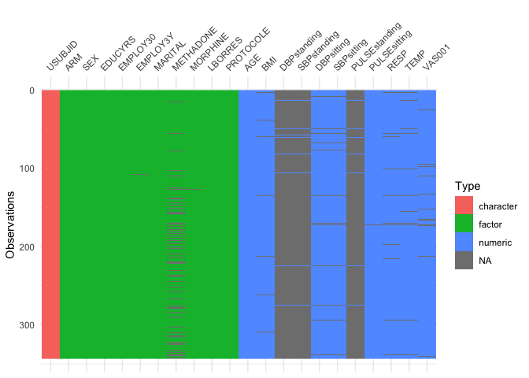

```r
# Global view of our dataframe and its data class structures
vis_dat(Dataset_01)
```

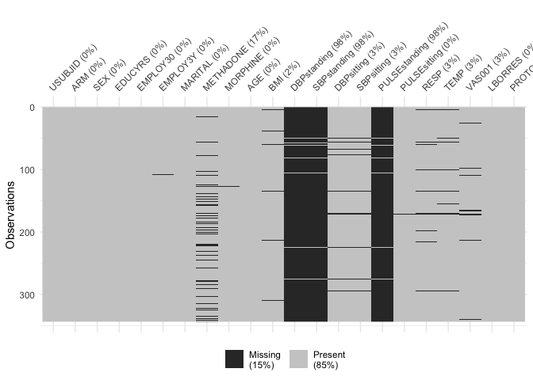

```r
# More emphasis on missing data
vis_miss(Dataset_01)
```

```r
# Correlation matrices are done above in the explore function which isn't visible in Rmarkdown
```

# 4 Objective 03 : Preprocessing the dataframe.

```r
# Preparing the dataset to apply ML algorithms.
# filling NA, One hot encoding, Normalizing
skim(Dataset_01)
Dataset_01_treated <- Dataset_01 %>%
  select(LBORRES, USUBJID, PROTOCOLE, ARM, AGE, SEX, BMI, METHADONE, MORPHINE, VAS001, EDUCYRS, EMPLOY30, EMPLOY3Y, MARITAL, DBPsitting, SBPsitting, PULSEsitting, RESP, TEMP) %>%
  mutate(PROTOCOLE = if_else(str_detect(PROTOCOLE, "^In"), "0", "1")) %>%
  mutate(PROTOCOLE = as.factor(PROTOCOLE)) %>%
  mutate(ARM = if_else(str_detect(ARM, "^BUP"), "0", "1")) %>%
  mutate(ARM = as.factor(ARM)) %>%
  mutate(SEX = if_else(str_detect(SEX, "F"), "0", "1")) %>%
  mutate(SEX = as.factor(SEX)) %>%
  mutate(METHADONE = if_else(str_detect(METHADONE, "^NEG"), "0", "1")) %>%
  mutate(METHADONE = as.factor(METHADONE)) %>%
  mutate(MORPHINE = if_else(str_detect(MORPHINE, "^NEG"), "0", "1")) %>%
  mutate(MORPHINE = as.factor(MORPHINE))

# Removing NA # https://www.kaggle.com/code/lmorgan95/missforest-the-best-imputation-algorithm/report
set.seed(70)
Dataset_IMP <- subset(Dataset_01_treated, select = -c(LBORRES, USUBJID))
imp_missForest <- missForest(Dataset_IMP, maxiter = 10, verbose = T)
Dataset_IMP <- imp_missForest$ximp

# USUBJID Not needed as we already extracted arm information in a seperate column
LBORRES <- Dataset_01_treated[, 1]
Dataset_01_treated <- cbind(LBORRES, Dataset_IMP)

# Normalizing values
preproc <- preProcess(Dataset_01_treated, method = "range")
DS01_norm <- predict(preproc, Dataset_01_treated)

# Dummy variables
dmy <- dummyVars(" ~ .", data = DS01_norm, fullRank=T)
DS01_norm_dummy <- data.frame(predict(dmy, newdata = DS01_norm)) #FullRank to choose one dummy for columns that has 2 values, ex GENDER.
DS01_norm_dummy <- DS01_norm_dummy %>% clean_names()
colnames(DS01_norm_dummy)[colnames(DS01_norm_dummy) == "lborres_1"] <- "Treatment_Results"
DS01_norm_dummy$Treatment_Results <- lfactor(DS01_norm_dummy$Treatment_Results, levels = 0:1, labels = c("Failure", "Success"))
DS01_norm_dummy$Treatment_Results <- as.factor(DS01_norm_dummy$Treatment_Results)

set.seed(70)
index <- createDataPartition(DS01_norm_dummy$Treatment_Results, p = 0.80, list = FALSE)
train <- DS01_norm_dummy[index,]
test <- DS01_norm_dummy[-index,]
testref <- DS01_norm_dummy[-index,]

TableSKIMR <- DS01_norm_dummy %>%
  skim() %>%
  dplyr::select(-skim_type)
```

```r
str(DS01_norm_dummy)
```

```
## 'data.frame':    343 obs. of  46 variables:
##  $ Treatment_Results                       : Factor w/ 2 levels "Failure","Success": 1 1 1 2 2 1 1 1 1 2 ...
##  $ protocole_1                             : num  0 0 0 0 0 0 0 0 0 0 ...
##  $ arm_1                                   : num  1 1 0 0 0 1 0 0 1 0 ...
##  $ age                                     : num  0.1826 0.4891 0.25 0.0449 0.0199 ...
##  $ sex_1                                   : num  0 0 1 1 0 1 1 1 1 0 ...
##  $ bmi                                     : num  0.141 0.702 0.163 0.271 0.217 ...
##  $ methadone_1                             : num  0 1 0 0 0 0 0 0 0 0 ...
##  $ morphine_1                              : num  1 0 1 0 1 0 1 0 0 1 ...
##  $ vas001                                  : num  0.38 0.16 0.5 0.56 0.92 0.07 0.52 0.44 0.07 0.69 ...
##  $ educyrs_8                               : num  0 0 0 0 0 0 0 0 0 0 ...
##  $ educyrs_9                               : num  0 0 0 0 0 0 0 0 0 0 ...
##  $ educyrs_10                              : num  0 0 0 0 0 0 0 0 0 0 ...
##  $ educyrs_11                              : num  0 0 0 0 1 0 0 1 0 1 ...
##  $ educyrs_12                              : num  0 0 0 0 0 0 1 0 0 0 ...
```

[output cut: 32 more lines]

# 5 Objective 04 : Applying ML models

## 5.1 Baseline accuracy

If our prediction are all “Failure” we get an Accuracy of 69% (Sens 0 no positive class). This should be the baseline we improve upon in both Accuracy and Sensitivity.

```r
test$Treatment_Results = "Failure"
test$Treatment_Results <- lfactor(test$Treatment_Results, levels = 0:1, labels = c("Failure", "Success"))
confusionMatrix(data = test$Treatment_Results, reference = testref$Treatment_Results, positive = "Success")
```

```
## Confusion Matrix and Statistics
##
##           Reference
## Prediction Failure Success
##    Failure      47      21
##    Success       0       0
##
##                Accuracy : 0.6912
##                  95% CI : (0.5674, 0.7976)
##     No Information Rate : 0.6912
##     P-Value [Acc > NIR] : 0.5587
##
##                   Kappa : 0
##
##  Mcnemar's Test P-Value : 1.275e-05
##
##             Sensitivity : 0.0000
##             Specificity : 1.0000
##          Pos Pred Value :    NaN
##          Neg Pred Value : 0.6912
##              Prevalence : 0.3088
##          Detection Rate : 0.0000
##    Detection Prevalence : 0.0000
##       Balanced Accuracy : 0.5000
##
##        'Positive' Class : Success
##
```

## 5.2 Feature selection

### 5.2.1 RFE

```r
## Feature selection using RFE (Recursive Feature Elimination)
# Selected variable : ARM, PROTOCOLE
set.seed(70)
Control <- rfeControl(functions=rfFuncs, method="cv", number=10)
Results <- rfe(DS01_norm[,2:18], DS01_norm[,1], sizes=c(1:16), metric = "RMSE", rfeControl=Control)
```

```
## [1] "ARM"       "PROTOCOLE"
```

### 5.2.2 SBF

```r
## Feature selection using SBF (Selection By Filtering)
# Selected variable : ARM (100%), MORPHINE (100%), PROTOCOLE (100%), SBPsitting (100%), PULSEsitting (60%)
RFwithGAM <- sbf(numeric_cols[,2:14], numeric_cols[,1],
                 sbfControl = sbfControl(functions = rfSBF,
                                         verbose = FALSE,
                                         method = "cv"))
print(RFwithGAM)
```

```
##
## Selection By Filter
##
## Outer resampling method: Cross-Validated (10 fold)
##
## Resampling performance:
##
##  Accuracy  Kappa AccuracySD KappaSD
##    0.7495 0.3566     0.0506  0.1199
##
## Using the training set, 7 variables were selected:
##    PROTOCOLE, ARM, MORPHINE, SBPsitting, PULSEsitting...
##
## During resampling, the top 5 selected variables (out of a possible 10):
##    ARM (100%), MORPHINE (100%), PROTOCOLE (100%), SBPsitting (90%), RESP (80%)
##
## On average, 6.5 variables were selected (min = 5, max = 10)
```

## 5.3 Model selection

### 5.3.1 Training multiple models simultaneously

```r
# Training multiple models
number <- 5
repeats <- 4
control <- trainControl(method = "cv",
                        classProbs = TRUE,
                        savePredictions = "final",
                        index = createResample(train$Treatment_Results, repeats*number),
                        summaryFunction = multiClassSummary,
                        allowParallel = TRUE)
set.seed(70)

model_list1 <- caretList(Treatment_Results ~ protocole_1+arm_1+morphine_1+sb_psitting+puls_esitting,
                         data = train,
                         trControl = control,
                         metric = "Accuracy",
                         methodList = my_models)
```

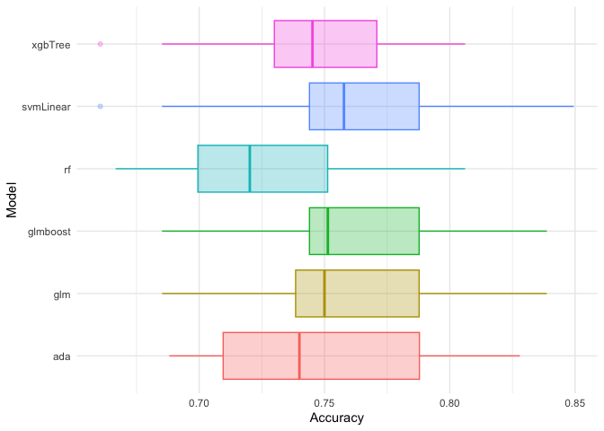

### 5.3.2 ROC Curve

To make the ROC curve simpler, we first plot it with all of our models, then filter by the top 3 performers, leaving a baseline model “GLM” on the graph to see the difference.

[figure not shown]

```r
res2 <- evalm(list(KNNalgo9, model_list1$ada, model_list1$glm, model_list1$xgbTree),
              gnames=c('Knn','Ada', 'Glm', 'XgbTree'), rlinethick=0.4, plots = "r", showplots = TRUE)
```

### 5.3.3 Chosen model : KNN

```r
## KNN algo
# All features. (ACC, SENS, SPEC - 73%, 19%, 97%)
# Feature selec. (ACC, SENS, SPEC - 82%, 42%, 100%)
set.seed(70)
KNNalgo9 <- train(Treatment_Results ~ protocole_1+arm_1+age+sex_1+morphine_1, data=train, method="knn", trControl = control,
                  tuneGrid=data.frame(k=seq(2,10,by=1)), metric = "Accuracy")
KNNalgo9res <- predict(KNNalgo9, newdata = test, type="raw")
KNNalgo9
```

```
## k-Nearest Neighbors
##
## 275 samples
##   5 predictor
##   2 classes: 'Failure', 'Success'
##
## No pre-processing
## Resampling: Cross-Validated (10 fold)
## Summary of sample sizes: 275, 275, 275, 275, 275, 275, ...
## Resampling results across tuning parameters:
##
##   k   logLoss   AUC        prAUC      Accuracy   Kappa      F1
##    2  8.517642  0.6319905  0.2655270  0.6485115  0.1911184  0.7426046
##    3  6.023070  0.6556297  0.3180954  0.6549753  0.1950466  0.7498986
##    4  4.603450  0.6659068  0.3679153  0.6740554  0.2273282  0.7666148
##    5  3.765715  0.6745049  0.4148462  0.6922058  0.2645738  0.7811918
##    6  3.066022  0.6893712  0.4441093  0.6893544  0.2559257  0.7793235
##    7  2.543901  0.7018514  0.4680636  0.7061379  0.2952551  0.7909225
##    8  2.020078  0.7070092  0.4990203  0.7150764  0.3040909  0.8002820
##    9  1.774425  0.7035895  0.5042845  0.7061076  0.2803576  0.7946361
##   10  1.533886  0.7101048  0.5273724  0.7113305  0.2890143  0.7995753
##   Sensitivity  Specificity  Pos_Pred_Value  Neg_Pred_Value  Precision
##   0.7460554    0.4495886    0.7440602       0.4490466       0.7440602
##   0.7628539    0.4317952    0.7427535       0.4636131       0.7427535
##   0.7902927    0.4335339    0.7499625       0.5009760       0.7499625
##   0.8112060    0.4468948    0.7597457       0.5427939       0.7597457
##   0.8079676    0.4406974    0.7573430       0.5263179       0.7573430
##   0.8216791    0.4646722    0.7674585       0.5627661       0.7674585
##   0.8408514    0.4513265    0.7672956       0.5721844       0.7672956
##   0.8379903    0.4311301    0.7606594       0.5576276       0.7606594
##   0.8472027    0.4287062    0.7615915       0.5695481       0.7615915
##   Recall     Detection_Rate  Balanced_Accuracy
##   0.7460554  0.5084895       0.5978220
##   0.7628539  0.5194665       0.5973245
##   0.7902927  0.5381714       0.6119133
##   0.8112060  0.5522092       0.6290504
##   0.8079676  0.5501455       0.6243325
##   0.8216791  0.5600275       0.6431757
##   0.8408514  0.5733160       0.6460889
##   0.8379903  0.5710396       0.6345602
##   0.8472027  0.5772603       0.6379545
##
## Accuracy was used to select the optimal model using the largest value.
## The final value used for the model was k = 8.
```

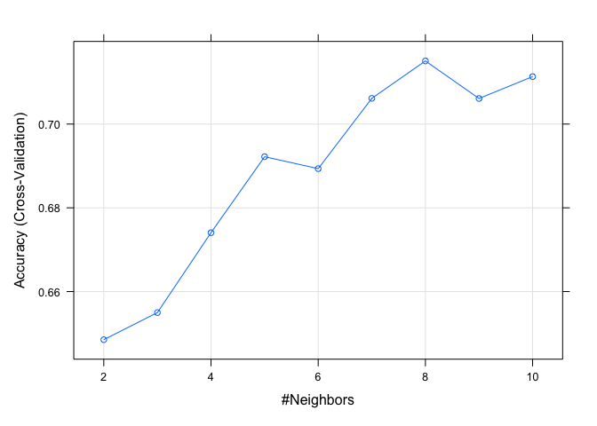

```r
plot(KNNalgo9)
```

```r
confusionMatrix(data = KNNalgo9res, reference = testref$Treatment_Results, positive = "Success")
```

```
## Confusion Matrix and Statistics
##
##           Reference
## Prediction Failure Success
##    Failure      47      13
##    Success       0       8
##
##                Accuracy : 0.8088
##                  95% CI : (0.6953, 0.8941)
##     No Information Rate : 0.6912
##     P-Value [Acc > NIR] : 0.0211246
##
##                   Kappa : 0.4597
##
##  Mcnemar's Test P-Value : 0.0008741
##
##             Sensitivity : 0.3810
##             Specificity : 1.0000
##          Pos Pred Value : 1.0000
##          Neg Pred Value : 0.7833
##              Prevalence : 0.3088
##          Detection Rate : 0.1176
##    Detection Prevalence : 0.1176
##       Balanced Accuracy : 0.6905
##
##        'Positive' Class : Success
##
```

Next step :

- using SMOTE for the imbalanced classification problem we have (38% sensitivity)
- feature engineering, modeling the existing data so that it can be more useful in our classification.
- adding more data from the other excel files and see their influence on our algorithms.
- try other CV methods.

# 6 Annex

## 6.1 Things learned

Things learned :

- No need to change random seed to find an optimal one, if values changes too much it means something is wrong with our model to begin with.
- Large mtry numbers in RF because of levels in factors.
- Different type of CV
- Difference between SBF & RFE
- Kappa metric
- Difference between test accuracy and train accuracy (overfitting)
- Accuracy paradox (high % while positives are not detected)
- AUC is just a number and it can be misleading, you need to see the ROC curve at a given speci/sens
- Never tune model after using the test set, model tuning should always be on the Validation set, as the test set doesn’t represent the whole distribution of the population you shouldn’t fit the model on it. It should be generalized.

## 6.2 R script

```r
require(tidyverse)
require(caret)
require(caretEnsemble)
require(missForest)
require(doParallel)
require(explore)
require(plyr)
require(janitor)
require(lfactors)
require(magrittr)
require(skimr)
require(tibble)
require(stringr)
require(kableExtra)
require(prettydoc)
require(rmdformats)
require(MLeval)
require(visdat)


#########################################################
### DM Table with variable that indicates the ARM. LB Table that indicates drug results and day.
dm <- read.csv("ascii-data-files nida-ctn-0001-20230318/dm.csv", header = T, dec = ".")
dm2 <- read.csv("ascii-data-files nida-ctn-0002-20230318/dm.csv", header = T, dec = ".")
lb <- read.csv("ascii-data-files nida-ctn-0001-20230318/lb.csv", header = T, dec = ".")
lb2 <- read.csv("ascii-data-files nida-ctn-0002-20230318/lb.csv", header = T, dec = ".")

#Criteria of success D13 or D14 with negative opoids results.
# Importing lb database containg opioid test results, and dm with arm.
dm3 <- dm %>% filter(ARM %in% c("CLONIDINE","BUPRENORPHINE/NALOXONE")) %>% select(USUBJID, ARM)
dm4 <- dm2 %>% filter(ARM %in% c("CLONIDINE","BUPRENORPHINE/NALOXONE")) %>% select (USUBJID, ARM)
lb3 <- lb %>% filter(EPOCH == "ACTIVE", VISITNUM %in% c(1:14)) #Missing 5 patients from lb3 compared to dm3 when applying this filter. as they are still in screening epoch but have already been assigned in dm database "01_018076" "01_027452" "01_058918" "01_063935" "01_067193".
lb4 <- lb2 %>% filter(EPOCH == "ACTIVE", VISITNUM %in% c(1:14)) #Missing 27 patients from lb4 compared to dm4 when applying this filter.

# Adding the ARM column.
list_df10 = list(lb3, dm3)
tabURINE <- list_df10 %>%
  reduce(full_join, by='USUBJID') %>%
  select("USUBJID", "LBTEST", "LBORRES", "LBSTAT", "LBREASND", "LBSPEC", "LBMETHOD", "VISIT", "VISITNUM", "LBDY", "LBDTC", "ARM") #113 patients

list_df11 = list(lb4, dm4)
tabURINE2 <- list_df11 %>%
  reduce(full_join, by='USUBJID') %>%
  select("USUBJID", "LBTEST", "LBORRES", "LBSTAT", "LBREASND", "LBSPEC", "LBMETHOD", "VISIT", "VISITNUM", "LBDY", "LBDTC", "ARM") #231 patients

# Merging both tables
TableURINE <- rbind(tabURINE, tabURINE2)

# Success criteria met for these patients with NEGATIVE test results, others are a Failure.
TableSuc <- TableURINE %>%
  filter(VISITNUM %in% c(13,14) ) %>%
  filter(LBTEST == "OPIATE") %>%
  filter(LBORRES == "NEGATIVE") %>%
  mutate(PROTOCOLE = if_else(str_detect(USUBJID, "^01"), "In-patient protocol", "Out-patient protocol")) %>%
  mutate(PROTOCOLE = as.factor(PROTOCOLE)) %>%
  filter(ARM %in% c("CLONIDINE","BUPRENORPHINE/NALOXONE")) %>%
  # Issue with patient 02_036130. Filtered again because after join there was one patient that had SCREEN FAILURE on DM4 but got to the final table through LB4 because he had active epoch tests, which doesn't make sense.
  arrange(VISITNUM) %>%
  select(USUBJID, LBORRES)

# TableAgg from Devoir 1, for more information please refer to Devoir 1.
dm <- read.csv("ascii-data-files nida-ctn-0001-20230318/dm.csv", header = T, dec = ".")
tabDM <- dm %>% select(USUBJID, ARM, AGE, SEX)
vs <- read.csv("ascii-data-files nida-ctn-0001-20230318/vs.csv", header = T, dec = ".")
tabTEMP <- vs %>% filter(EPOCH=="SCREENING", VSTESTCD=="TEMP") %>% select(USUBJID, VSORRES)
tabTEMP <- distinct(tabTEMP)
colnames(tabTEMP) <- c("USUBJID", "TEMP")
tabRESP <- vs %>% filter(EPOCH=="SCREENING", VSTESTCD=="RESP") %>% select(USUBJID, VSORRES)
tabRESP <- distinct(tabRESP)
colnames(tabRESP) <- c("USUBJID", "RESP")
tabPULSEsitting <- vs %>% filter(EPOCH=="SCREENING", VSPOS=="SITTING", VSTESTCD=="PULSE") %>% select(USUBJID, VSORRES)
tabPULSEsitting <- distinct(tabPULSEsitting)
colnames(tabPULSEsitting) <- c("USUBJID", "PULSEsitting")
tabPULSEstanding <- vs %>% filter(EPOCH=="SCREENING", VSPOS=="STANDING", VSTESTCD=="PULSE") %>% select(USUBJID, VSORRES)
tabPULSEstanding <- distinct(tabPULSEstanding)
colnames(tabPULSEstanding) <- c("USUBJID", "PULSEstanding")
tabSBPsitting <- vs %>% filter(EPOCH=="SCREENING", VSPOS=="SITTING", VSTESTCD=="SBP") %>% select(USUBJID, VSORRES)
tabSBPsitting <- distinct(tabSBPsitting)
colnames(tabSBPsitting) <- c("USUBJID", "SBPsitting")
tabSBPstanding <- vs %>% filter(EPOCH=="SCREENING", VSPOS=="STANDING", VSTESTCD=="SBP") %>% select(USUBJID, VSORRES)
tabSBPstanding <- distinct(tabSBPstanding)
colnames(tabSBPstanding) <- c("USUBJID", "SBPstanding")
tabDBPsitting <- vs %>% filter(EPOCH=="SCREENING", VSPOS=="SITTING", VSTESTCD=="DBP") %>% select(USUBJID, VSORRES)
tabDBPsitting <- distinct(tabDBPsitting)
colnames(tabDBPsitting) <- c("USUBJID", "DBPsitting")
tabDBPstanding <- vs %>% filter(EPOCH=="SCREENING", VSPOS=="STANDING", VSTESTCD=="DBP") %>% select(USUBJID, VSORRES)
tabDBPstanding <- distinct(tabDBPstanding)
colnames(tabDBPstanding) <- c("USUBJID", "DBPstanding")
tabHEIGHT <- vs %>% filter(EPOCH=="SCREENING", VSTESTCD=="HEIGHT") %>% select(USUBJID, VSORRES)
tabHEIGHT <- distinct(tabHEIGHT)
colnames(tabHEIGHT) <- c("USUBJID", "HEIGHT")
tabWEIGHT <- vs %>% filter(EPOCH=="SCREENING", VSTESTCD=="WEIGHT") %>% select(USUBJID, VSORRES)
tabWEIGHT <- distinct(tabWEIGHT)
colnames(tabWEIGHT) <- c("USUBJID", "WEIGHT")
calculate_bmi <- function(dataframe, height_col, weight_col, bmi_col) {
  height_meters <- dataframe[[height_col]] * 0.0254
  weight_kg <- dataframe[[weight_col]] * 0.453592
  bmi <- weight_kg / (height_meters^2)
  dataframe[[bmi_col]] <- bmi
  return(dataframe)
}
tabBMI <- left_join(tabHEIGHT, tabWEIGHT, by="USUBJID")
tabBMI <- calculate_bmi(tabBMI, "HEIGHT", "WEIGHT", "BMI") %>% select("USUBJID", "BMI")
list_df1 = list(tabBMI, tabDBPsitting, tabSBPsitting, tabDBPstanding, tabSBPstanding, tabPULSEsitting, tabPULSEstanding, tabRESP, tabTEMP)
tabVS <- list_df1 %>% reduce(full_join, by='USUBJID')
sc <- read.csv("ascii-data-files nida-ctn-0001-20230318/sc.csv", header = T, dec = ".")
tabMARITAL <- sc %>% filter(SCTESTCD=="MARITAL") %>% select(USUBJID, SCORRES)
tabMARITAL <- distinct(tabMARITAL)
colnames(tabMARITAL) <- c("USUBJID", "MARITAL")
tabEDUC <- sc %>% filter(SCTESTCD=="EDUCYRS") %>% select(USUBJID, SCORRES)
tabEDUC <- distinct(tabEDUC)
colnames(tabEDUC) <- c("USUBJID", "EDUCYRS")
tabEMPLOY30 <- sc %>% filter(SCTESTCD=="EMPLOY30") %>% select(USUBJID, SCORRES)
tabEMPLOY30 <- distinct(tabEMPLOY30)
colnames(tabEMPLOY30) <- c("USUBJID", "EMPLOY30")
tabEMPLOY3Y <- sc %>% filter(SCTESTCD=="EMPLOY3Y") %>% select(USUBJID, SCORRES)
tabEMPLOY3Y <- distinct(tabEMPLOY3Y)
colnames(tabEMPLOY3Y) <- c("USUBJID", "EMPLOY3Y")
tabEMPLOY <- left_join(tabEMPLOY30, tabEMPLOY3Y, by="USUBJID")
list_df2 = list(tabEDUC, tabEMPLOY, tabMARITAL)
tabSC <- list_df2 %>% reduce(full_join, by='USUBJID')
lb <- read.csv("ascii-data-files nida-ctn-0001-20230318/lb.csv", header = T, dec = ".")
tabMETHADONE <- lb %>% filter(EPOCH=="SCREENING", LBTESTCD=="METHADON", LBMETHOD=="CENTRAL LAB") %>% select(USUBJID, LBORRES)
tabMETHADONE <- distinct(tabMETHADONE)
colnames(tabMETHADONE) <- c("USUBJID", "METHADONE")
tabMORPHINE <- lb %>% filter(EPOCH=="SCREENING", LBTESTCD=="MORPHINE") %>% select(USUBJID, LBORRES)
tabMORPHINE <- distinct(tabMORPHINE)
colnames(tabMORPHINE) <- c("USUBJID", "MORPHINE")
list_df3 = list(tabMETHADONE, tabMORPHINE)
tabLB <- list_df3 %>% reduce(full_join, by='USUBJID')
qs <- read.csv("ascii-data-files nida-ctn-0001-20230318/qs.csv", header = T, dec = ".")
tabQS <- qs %>% filter(EPOCH=="SCREENING", QSTESTCD=="VAS001") %>% select(USUBJID, QSORRES)
tabQS <- distinct(tabQS)
colnames(tabQS) <- c("USUBJID", "VAS001")
list_df4 = list(tabDM, tabSC, tabVS, tabQS, tabLB)
tabALL_01 <- list_df4 %>% reduce(full_join, by='USUBJID')
dm2 <- read.csv("ascii-data-files nida-ctn-0002-20230318/dm.csv", header = T, dec = ".")
tabDM2 <- dm2 %>% select(USUBJID, ARM, AGE, SEX)
vs2 <- read.csv("ascii-data-files nida-ctn-0002-20230318/vs.csv", header = T, dec = ".")
tabTEMP2 <- vs2 %>% filter(EPOCH=="SCREENING", VSTESTCD=="TEMP") %>% select(USUBJID, VSORRES)
tabTEMP2 <- distinct(tabTEMP2)
colnames(tabTEMP2) <- c("USUBJID", "TEMP")
tabTEMP2$TEMP[tabTEMP2$TEMP == 999.9] <- 99.9
tabRESP2 <- vs2 %>% filter(EPOCH=="SCREENING", VSTESTCD=="RESP") %>% select(USUBJID, VSORRES)
tabRESP2 <- distinct(tabRESP2)
colnames(tabRESP2) <- c("USUBJID", "RESP")
tabPULSEsitting2 <- vs2 %>% filter(EPOCH=="SCREENING", VSPOS=="SITTING", VSTESTCD=="PULSE") %>% select(USUBJID, VSORRES)
tabPULSEsitting2 <- distinct(tabPULSEsitting2)
colnames(tabPULSEsitting2) <- c("USUBJID", "PULSEsitting")
tabPULSEstanding2 <- vs2 %>% filter(EPOCH=="SCREENING", VSPOS=="STANDING", VSTESTCD=="PULSE") %>% select(USUBJID, VSORRES)
tabPULSEstanding2 <- distinct(tabPULSEstanding2)
colnames(tabPULSEstanding2) <- c("USUBJID", "PULSEstanding")
tabSBPsitting2 <- vs2 %>% filter(EPOCH=="SCREENING", VSPOS=="SITTING", VSTESTCD=="SBP") %>% select(USUBJID, VSORRES)
tabSBPsitting2 <- distinct(tabSBPsitting2)
colnames(tabSBPsitting2) <- c("USUBJID", "SBPsitting")
tabSBPstanding2 <- vs2 %>% filter(EPOCH=="SCREENING", VSPOS=="STANDING", VSTESTCD=="SBP") %>% select(USUBJID, VSORRES)
tabSBPstanding2 <- distinct(tabSBPstanding2)
colnames(tabSBPstanding2) <- c("USUBJID", "SBPstanding")
tabDBPsitting2 <- vs2 %>% filter(EPOCH=="SCREENING", VSPOS=="SITTING", VSTESTCD=="DBP") %>% select(USUBJID, VSORRES)
tabDBPsitting2 <- distinct(tabDBPsitting2)
colnames(tabDBPsitting2) <- c("USUBJID", "DBPsitting")
tabDBPstanding2 <- vs2 %>% filter(EPOCH=="SCREENING", VSPOS=="STANDING", VSTESTCD=="DBP") %>% select(USUBJID, VSORRES)
tabDBPstanding2 <- distinct(tabDBPstanding2)
colnames(tabDBPstanding2) <- c("USUBJID", "DBPstanding")
tabHEIGHT <- vs2 %>% filter(EPOCH=="SCREENING", VSTESTCD=="HEIGHT") %>% select(USUBJID, VSORRES)
tabHEIGHT <- distinct(tabHEIGHT)
colnames(tabHEIGHT) <- c("USUBJID", "HEIGHT")
tabWEIGHT <- vs2 %>% filter(EPOCH=="SCREENING", VSTESTCD=="WEIGHT") %>% select(USUBJID, VSORRES)
tabWEIGHT <- distinct(tabWEIGHT)
colnames(tabWEIGHT) <- c("USUBJID", "WEIGHT")
tabHEIGHT2 <- vs2 %>% filter(EPOCH=="SCREENING", VSTESTCD=="HEIGHT") %>% select(USUBJID, VSORRES)
tabHEIGHT2 <- distinct(tabHEIGHT2)
colnames(tabHEIGHT2) <- c("USUBJID", "HEIGHT")
tabHEIGHT2$HEIGHT[tabHEIGHT2$HEIGHT == 715] <- 71
tabWEIGHT2 <- vs2 %>% filter(EPOCH=="SCREENING", VSTESTCD=="WEIGHT") %>% select(USUBJID, VSORRES)
tabWEIGHT2 <- distinct(tabWEIGHT2)
colnames(tabWEIGHT2) <- c("USUBJID", "WEIGHT")
calculate_bmi <- function(dataframe, height_col, weight_col, bmi_col) {
  height_meters <- dataframe[[height_col]] * 0.0254
  weight_kg <- dataframe[[weight_col]] * 0.453592
  bmi <- weight_kg / (height_meters^2)
  dataframe[[bmi_col]] <- bmi
  return(dataframe)
}
tabBMI2 <- left_join(tabHEIGHT2, tabWEIGHT2, by="USUBJID")
tabBMI2 <- calculate_bmi(tabBMI2, "HEIGHT", "WEIGHT", "BMI") %>% select("USUBJID", "BMI")
list_df5 = list(tabBMI2, tabDBPstanding2, tabSBPstanding2, tabDBPsitting2, tabSBPsitting2, tabPULSEstanding2, tabPULSEsitting2, tabRESP2, tabTEMP2)
tabVS2 <- list_df5 %>% reduce(full_join, by='USUBJID')
sc2 <- read.csv("ascii-data-files nida-ctn-0002-20230318/sc.csv", header = T, dec = ".")
tabMARITAL2 <- sc2 %>% filter(SCTESTCD=="MARITAL") %>% select(USUBJID, SCORRES)
tabMARITAL2 <- distinct(tabMARITAL2)
colnames(tabMARITAL2) <- c("USUBJID", "MARITAL")
tabEDUC2 <- sc2 %>% filter(SCTESTCD=="EDUCYRS") %>% select(USUBJID, SCORRES)
tabEDUC2 <- distinct(tabEDUC2)
colnames(tabEDUC2) <- c("USUBJID", "EDUCYRS")
tabEMPLOY302 <- sc2 %>% filter(SCTESTCD=="EMPLOY30") %>% select(USUBJID, SCORRES)
tabEMPLOY302 <- distinct(tabEMPLOY302)
colnames(tabEMPLOY302) <- c("USUBJID", "EMPLOY30")
tabEMPLOY3Y2 <- sc2 %>% filter(SCTESTCD=="EMPLOY3Y") %>% select(USUBJID, SCORRES)
tabEMPLOY3Y2 <- distinct(tabEMPLOY3Y2)
colnames(tabEMPLOY3Y2) <- c("USUBJID", "EMPLOY3Y")
tabEMPLOY2 <- left_join(tabEMPLOY302, tabEMPLOY3Y2, by="USUBJID")
list_df6 = list(tabEDUC2, tabEMPLOY2, tabMARITAL2)
tabSC2 <- list_df6 %>% reduce(full_join, by='USUBJID')
lb2 <- read.csv("ascii-data-files nida-ctn-0002-20230318/lb.csv", header = T, dec = ".")
tabMETHADONE2 <- lb2 %>% filter(EPOCH=="SCREENING", LBTESTCD=="METHADON", LBMETHOD=="CENTRAL LAB") %>% select(USUBJID, LBORRES)
```

```r
tabMETHADONE2 <- distinct(tabMETHADONE2)
colnames(tabMETHADONE2) <- c("USUBJID", "METHADONE")
tabMORPHINE2 <- lb2 %>% filter(EPOCH=="SCREENING", LBTESTCD=="MORPHINE") %>% select(USUBJID, LBORRES)
tabMORPHINE2 <- distinct(tabMORPHINE2)
colnames(tabMORPHINE2) <- c("USUBJID", "MORPHINE")
list_df7 = list(tabMETHADONE2, tabMORPHINE2)
tabLB2 <- list_df7 %>% reduce(full_join, by='USUBJID')
qs2 <- read.csv("ascii-data-files nida-ctn-0002-20230318/qs.csv", header = T, dec = ".")
tabQS2 <- qs2 %>% filter(EPOCH=="SCREENING", QSTESTCD=="VAS001") %>% select(USUBJID, QSORRES)
tabQS2 <- distinct(tabQS2)
colnames(tabQS2) <- c("USUBJID", "VAS001")
list_df8 = list(tabDM2, tabSC2, tabVS2, tabQS2, tabLB2)
tabALL_02 <- list_df8 %>% reduce(full_join, by='USUBJID')
TableALL <- rbind(tabALL_02, tabALL_01)
TableALL$VAS001 <- as.numeric(TableALL$VAS001)

TableAgg <- TableALL %>%
  group_by(USUBJID, ARM, SEX, EDUCYRS, EMPLOY30, EMPLOY3Y, MARITAL, METHADONE, MORPHINE) %>%
  dplyr::summarise(across(where(is.numeric), ~ mean(.x, na.rm = TRUE))) %>%
  mutate(dplyr::across(everything(), ~replace_na(.x, NA)))

TableAgg <- distinct(TableAgg) %>%
  filter(!(ARM == "")) %>%
  filter(!(ARM == "SCREEN FAILURE"))
TableAgg$ARM <- as.factor(TableAgg$ARM)
TableAgg$SEX <- as.factor(TableAgg$SEX)
TableAgg$EDUCYRS <- as.numeric(TableAgg$EDUCYRS)
TableAgg$EMPLOY30 <- as.factor(TableAgg$EMPLOY30)
TableAgg$EMPLOY3Y <- as.factor(TableAgg$EMPLOY3Y)
TableAgg$MARITAL <- as.factor(TableAgg$MARITAL)
TableAgg$METHADONE <- as.factor(TableAgg$METHADONE)
TableAgg$MORPHINE <- as.factor(TableAgg$MORPHINE)
TableAgg <- as.data.frame(TableAgg)


# Merging this table with the initial table we have from Devoir 1
# Now we have the table with Success 1 or Failure 0 in LBORRES column.
list_df20 = list(TableAgg, TableSuc)
Dataset_01 <- list_df20 %>%
  reduce(full_join, by='USUBJID') %>%
  mutate(PROTOCOLE = if_else(str_detect(USUBJID, "^01"), "In-patient protocol", "Out-patient protocol")) %>%
  mutate(PROTOCOLE = as.factor(PROTOCOLE)) %>%
  mutate(LBORRES = if_else(is.na(LBORRES), "0", LBORRES)) %>%
  mutate(LBORRES = if_else(str_detect(LBORRES, "NEGATIVE"), "1", "0")) %>%
  mutate(LBORRES = as.factor(LBORRES)) %>%
  mutate(EDUCYRS = as.factor(EDUCYRS))

# EVA
# Trends to check : Protocole, arm, sex & age effect on Treatement results LBORRES
# explore(DS01_norm)

# Preparing the dataset to apply ML algorithms.
# filling NA, One hot encoding, Normalizing
skim(Dataset_01)
Dataset_01_treated <- Dataset_01 %>%
  select(LBORRES, USUBJID, PROTOCOLE, ARM, AGE, SEX, BMI, METHADONE, MORPHINE, VAS001, EDUCYRS, EMPLOY30, EMPLOY3Y, MARITAL, DBPsitting, SBPsitting, PULSEsitting, RESP, TEMP) %>%
  mutate(PROTOCOLE = if_else(str_detect(PROTOCOLE, "^In"), "0", "1")) %>%
  mutate(PROTOCOLE = as.factor(PROTOCOLE)) %>%
  mutate(ARM = if_else(str_detect(ARM, "^BUP"), "0", "1")) %>%
  mutate(ARM = as.factor(ARM)) %>%
  mutate(SEX = if_else(str_detect(SEX, "F"), "0", "1")) %>%
  mutate(SEX = as.factor(SEX)) %>%
  mutate(METHADONE = if_else(str_detect(METHADONE, "^NEG"), "0", "1")) %>%
  mutate(METHADONE = as.factor(METHADONE)) %>%
  mutate(MORPHINE = if_else(str_detect(MORPHINE, "^NEG"), "0", "1")) %>%
  mutate(MORPHINE = as.factor(MORPHINE))

# Removing NA # https://www.kaggle.com/code/lmorgan95/missforest-the-best-imputation-algorithm/report
set.seed(70)
Dataset_IMP <- subset(Dataset_01_treated, select = -c(LBORRES, USUBJID))
imp_missForest <- missForest(Dataset_IMP, maxiter = 10, verbose = T)
Dataset_IMP <- imp_missForest$ximp
# USUBJID Not needed as we already extracted arm information in a seperate column
LBORRES <- Dataset_01_treated[, 1]
Dataset_01_treated <- cbind(LBORRES, Dataset_IMP)

# Normalizing values
preproc <- preProcess(Dataset_01_treated, method = "range")
DS01_norm <- predict(preproc, Dataset_01_treated)

#DS01_norm$LBORRES <- revalue(DS01_norm$LBORRES, c("0"="Zero", "1"="One"))
#DS01_norm$LBORRES <- relevel(DS01_norm$LBORRES, ref = "One")

# Dummy variables
dmy <- dummyVars(" ~ .", data = DS01_norm, fullRank=T)
DS01_norm_dummy <- data.frame(predict(dmy, newdata = DS01_norm)) #FullRank to choose one dummy for columns that has 2 values, ex GENDER.
DS01_norm_dummy <- DS01_norm_dummy %>% clean_names()
colnames(DS01_norm_dummy)[colnames(DS01_norm_dummy) == "lborres_1"] <- "Treatment_Results"
DS01_norm_dummy$Treatment_Results <- lfactor(DS01_norm_dummy$Treatment_Results, levels = 0:1, labels = c("Failure", "Success"))
DS01_norm_dummy$Treatment_Results <- as.factor(DS01_norm_dummy$Treatment_Results)

set.seed(70)
index <- createDataPartition(DS01_norm_dummy$Treatment_Results, p = 0.80, list = FALSE)
train <- DS01_norm_dummy[index,]
test <- DS01_norm_dummy[-index,]
testref <- DS01_norm_dummy[-index,]




















# If our prediction are all "Failure" we get an Accuracy of 69% (Accuracy paradox).
# This should be the baseline we improve upon in both Accuracy and Sensitivity.
# https://deepchecks.com/how-to-check-the-accuracy-of-your-machine-learning-model/
test$Treatment_Results = "Failure"
test$Treatment_Results <- lfactor(test$Treatment_Results, levels = 0:1, labels = c("Failure", "Success"))
confusionMatrix(data = test$Treatment_Results, reference = testref$Treatment_Results, positive = "Success")


# https://jtr13.github.io/cc21fall2/feature-selection-in-r.html
## Feature selection using RFE (Recursive Feature Elimination)
# Selected variable : ARM, PROTOCOLE
set.seed(70)
Control <- rfeControl(functions=rfFuncs, method="cv", number=10)
Results <- rfe(DS01_norm[,2:18], DS01_norm[,1], sizes=c(1:16), metric = "Kappa", rfeControl=Control)
print(Results)
predictors(Results)
plot(Results)

## Feature selection using SBF (Selection By Filtering)
# Selected variable : ARM (100%), MORPHINE (100%), PROTOCOLE (100%), SBPsitting (100%), PULSEsitting (60%)
# https://stackoverflow.com/questions/39922359/does-sbf-use-metric-argument-to-optimize-model
DS01_norm$LBORRES <- as.numeric(DS01_norm$LBORRES)
DS01_norm$PROTOCOLE <- as.numeric(DS01_norm$PROTOCOLE)
DS01_norm$ARM <- as.numeric(DS01_norm$ARM)
DS01_norm$SEX <- as.numeric(DS01_norm$SEX)
DS01_norm$METHADONE <- as.numeric(DS01_norm$METHADONE)
DS01_norm$MORPHINE <- as.numeric(DS01_norm$MORPHINE)
```

```r
numeric_cols <- DS01_norm %>% select_if(is.numeric)

numeric_cols$LBORRES <- numeric_cols$LBORRES - 1
numeric_cols$PROTOCOLE <- numeric_cols$PROTOCOLE - 1
numeric_cols$ARM <- numeric_cols$ARM - 1
numeric_cols$SEX <- numeric_cols$SEX - 1
numeric_cols$METHADONE <- numeric_cols$METHADONE - 1
numeric_cols$MORPHINE <- numeric_cols$MORPHINE -1

numeric_cols$LBORRES <- as.factor(numeric_cols$LBORRES)


RFwithGAM <- sbf(numeric_cols[,2:14], numeric_cols[,1],
                 sbfControl = sbfControl(functions = rfSBF,
                                         verbose = FALSE,
                                         method = "cv"))
RFwithGAM


## Algorithm selection
# https://datascience.stackexchange.com/questions/10745/which-of-the-180-algorithms-in-rs-caret-package-are-feasible
all_model <- modelLookup()
classification_model <- all_model %>%
  filter(forClass == TRUE, !duplicated(model))

# Packages that will be used for training these models:
all_packages <- sapply(classification_model$model,
                       function(x) {
                         x %>% getModelInfo() %>% .[[1]] %>% .[["library"]]}) %>% unlist()

all_packages <- all_packages[!duplicated(all_packages)]

your_packages <- installed.packages() %>%
  as.data.frame() %>%
  pull(Package) %>%
  as.character()

cannot_installed <- c("adaptDA", "CHAID", "sparsediscrim", "elmNN", "gpls",
                      "logicFS", "FCNN4R", "mxnet", "vbmp")

ml_not_used <- c("amdai", "chaid", "dda", "elm", "gpls",
                 "logicBag", "mlpSGD1", "mxnet", "vbmpRadial")

registerDoParallel(cores = detectCores() - 1)
additional_package <- all_packages[!all_packages %in% your_packages]
additional_package <- all_packages[!all_packages %in% cannot_installed]
additional_package %>% length()
should_use_ml <- classification_model %>%
  filter(!model %in% ml_not_used)
all_model <- should_use_ml$model
my_models <- all_model[c(1,51, 52, 130, 161, 182)]

# Training multiple models
# https://github.com/tobigithub/caret-machine-learning/blob/master/caret-cv/HAR-all-CV-methods.R
number <- 5
repeats <- 4
control <- trainControl(method = "cv",
                        classProbs = TRUE,
                        savePredictions = "final",
                        index = createResample(train$Treatment_Results, repeats*number),
                        summaryFunction = multiClassSummary,
                        allowParallel = TRUE)
set.seed(70)

model_list1 <- caretList(Treatment_Results ~ protocole_1+arm_1+morphine_1+sb_psitting+puls_esitting,
                         data = train,
                         trControl = control,
                         metric = "Accuracy",
                         methodList = my_models)

# Plotting with accuracy the different models:
list_of_results <- lapply(my_models, function(x) {model_list1[[x]]$resample})
df_results <- do.call("bind_rows", list_of_results)
df_results %<>% mutate(Model = lapply(my_models, function(x) {rep(x, number*repeats)}) %>% unlist())
df_results %>%
  select(Accuracy, Model) %>%
  ggplot(aes(Model, Accuracy, fill = Model, color = Model)) +
  geom_boxplot(show.legend = FALSE, alpha = 0.3) +
  theme_minimal() +
  coord_flip()



## Random forest
# All features resulting in not so optimal results. (ACC, SENS, SPEC - 76%, 38%, 93%)
# With features selection, we get optimal results. (ACC, SENS, SPEC - 80%, 47%, 95%)
# https://datascience.stackexchange.com/questions/28426/train-accuracy-vs-test-accuracy-vs-confusion-matrix
RFmodel <- predict(model_list1$rf, newdata = test, type="raw")
model_list1$rf #73% accuracy, difference between train accuracy and test acc is the overfitting
confusionMatrix(data = RFmodel, reference = testref$Treatment_Results, positive = "Success")


## Logistic regression
# All features. (ACC, SENS, SPEC - 72%, 28%, 91%)
# Feature selec. (ACC, SENS, SPEC - 78%, 42%, 93%)
set.seed(70)
LRmodel <- predict(model_list1$glm, newdata = test, type="raw")
model_list1$glm #77% training accuracy
confusionMatrix(data = LRmodel, reference = testref$Treatment_Results, positive = "Success")


## xgbTree
# All features. (ACC, SENS, SPEC - 67%, 23%, 87%)
# Feature selec. (ACC, SENS, SPEC - 76%, 38%, 93%)
set.seed(70)
xgbTreemodel <- predict(model_list1$xgbTree, newdata = test, type="raw")
model_list1$xgbTree #75% training accuracy
confusionMatrix(data = xgbTreemodel, reference = testref$Treatment_Results, positive = "Success")

## glmboost
# All features. (ACC, SENS, SPEC - 67%, 23%, 87%)
# Feature selec. (ACC, SENS, SPEC - 77%, 42%, 93%)
set.seed(70)
glmboostmodel <- predict(model_list1$glmboost, newdata = test, type="raw")
model_list1$glmboost #77% training accuracy
confusionMatrix(data = glmboostmodel, reference = testref$Treatment_Results, positive = "Success")


## svmLinear
# All features. (ACC, SENS, SPEC - 67%, 23%, 87%)
# Feature selec. (ACC, SENS, SPEC - 77%, 42%, 93%)
set.seed(70)
svmmodel <- predict(model_list1$svmLinear, newdata = test, type="raw")
model_list1$svmLinear #77% training accuracy
confusionMatrix(data = svmmodel, reference = testref$Treatment_Results, positive = "Success")


## ada
# All features. (ACC, SENS, SPEC - 67%, 23%, 87%)
# Feature selec. (ACC, SENS, SPEC - 76%, 28%, 97%)
set.seed(70)
adamodel <- predict(model_list1$ada, newdata = test, type="raw")
model_list1$ada #76% training accuracy
confusionMatrix(data = adamodel, reference = testref$Treatment_Results, positive = "Success")
m2 = data.frame(adamodel, testref$Treatment_Results)


## KNN algo
# All features. (ACC, SENS, SPEC - 73%, 19%, 97%)
# Feature selec. (ACC, SENS, SPEC - 82%, 42%, 100%)
set.seed(70)
KNNalgo9 <- train(Treatment_Results ~ protocole_1+arm_1+age+sex_1+morphine_1, data=train, method="knn", trControl = control,
                  tuneGrid=data.frame(k=seq(2,10,by=1)), metric = "Accuracy")
KNNalgo9res <- predict(KNNalgo9, newdata = test, type="raw")
KNNalgo9
plot(KNNalgo9)
confusionMatrix(data = KNNalgo9res, reference = testref$Treatment_Results, positive = "Success")


#https://alonhzn.medium.com/the-fallacy-of-an-roc-curve-on-a-test-set-c96d8fdf774
#https://discuss.boardinfinity.com/t/should-one-build-roc-curve-on-train-data-or-test-data/8039
#https://stats.stackexchange.com/questions/19048/what-is-the-difference-between-test-set-and-validation-set
#https://cran.r-project.org/web/packages/MLeval/vignettes/introduction.pdf
# Running ROCAUC on test or train? check links above
res2 <- evalm(list(KNNalgo9, model_list1$ada, model_list1$glm, model_list1$xgbTree),
              gnames=c('Knn','Ada', 'Glm', 'XgbTree'), rlinethick=0.4, plots = "r", showplots = TRUE)
```

```r
res2$cc


# https://stackoverflow.com/questions/62827779/roc-curve-for-the-testing-set-using-caret-package
# predict from several models
predicted_xgb <- predict(model_xgb, newdata =  testData3, type = "prob")
predicted_adaboost <- predict(model_adaboost, newdata =  testData3, type = "prob")
predicted_rf <- predict(model_rf, newdata =  testData3, type = "prob")

# append necessary columns
predicted_xgb$obs <- testData3$pred_group
predicted_xgb$Group <- "xgb"
predicted_adaboost$obs <- testData3$pred_group
predicted_adaboost$Group <- "adaboost"
predicted_rf$obs <- testData3$pred_group
predicted_rf$Group <- "rf"

#combine
combo_df <- rbind(predicted_xgb, predicted_adaboost, predicted_rf)

#evaluate
test2 <- evalm(combo_df)



?evalm
Sonar <- as.data.frame(Sonar)
# Ensembling models :
# https://cran.r-project.org/web/packages/caretEnsemble/vignettes/caretEnsemble-intro.html
model_list <- caretList(Treatment_Results ~ protocole_1+arm_1+morphine_1+sb_psitting+puls_esitting, data=train,
                        trControl=control,
                        methodList=c("glm", "rf"))

Combinedmodel <- predict(model_list, newdata = test)
model_list #73% accuracy, difference between train accuracy and test acc is the overfitting
confusionMatrix(data = Combinedmodel, reference = testref$Treatment_Results, positive = "Success")
Combinedmodel

modelCor(resamples(model_list))

my_control <- trainControl(
  method="boot",
  number=repeats*number,
  savePredictions="final",
  classProbs=TRUE,
  index=createResample(train$Treatment_Results, repeats*number),
  summaryFunction=twoClassSummary
)

glm_ensemble <- caretStack(
  model_list,
  method="glm",
  metric="ROC",
  trControl=my_control)

model_preds2 <- model_preds
model_preds2$ensemble <- predict(glm_ensemble, newdata=testing, type="prob")
CF <- coef(glm_ensemble$ens_model$finalModel)[-1]
colAUC(model_preds2, testing$Class)

########################################################
# Adding more data from different tables :

###CM Table with variables xxx
#EPOCH, CMDOSU(grams), VISIT, VISITNUM(which refered to CMSPID day taken medication all were 0 baseline), had one unique when filter was applied so i deleted them
cm <- read.csv("ascii-data-files nida-ctn-0001-20230318/cm.csv", header = T, dec = ".")

tabCM <- cm %>%
  filter(EPOCH=="SCREENING") %>%
  select(USUBJID, CMTRT, CMINDC, CMDOSTOT, CMSPID)
#mutate(CMDOSTOT = replace_na(CMDOSTOT, 0.000)) %>%
#mutate(CMSPID = replace_na(CMSPID, 0))

tabCM$CMSPID <- as.factor(tabCM$CMSPID)

tabCM$CMTRT[tabCM$CMTRT == "APPLESOL"] <- "APLISOL"
tabCM$CMTRT[tabCM$CMTRT == "APPLISOC"] <- "APLISOL"
tabCM$CMTRT[tabCM$CMTRT == "APPLISOL"] <- "APLISOL"
tabCM$CMTRT[tabCM$CMTRT == "CHONIDINE"] <- "CLONIDINE"
tabCM$CMTRT[tabCM$CMTRT == "CLONDINE"] <- "CLONIDINE"
tabCM$CMTRT[tabCM$CMTRT == "CLONIDINE PATCH"] <- "CLONIDINE"
tabCM$CMTRT[tabCM$CMTRT == "ASPRIN"] <- "ASPIRIN"
tabCM$CMTRT[tabCM$CMTRT == "IBP"] <- "IBUPROFEN"
tabCM$CMTRT[tabCM$CMTRT == "IMNODIUM"] <- "IMODIUM"
tabCM$CMTRT[tabCM$CMTRT == "KKAOPECTATE"] <- "KAOPECTATE"
tabCM$CMTRT[tabCM$CMTRT == "multivitamin"] <- "MULTIVITAMIN"
tabCM$CMTRT[tabCM$CMTRT == "MULTI VITAMIN"] <- "MULTIVITAMIN"
tabCM$CMTRT[tabCM$CMTRT == "MVI"] <- "MULTIVITAMIN"
tabCM$CMTRT[tabCM$CMTRT == "MOTRIN (IBUPROFEN)"] <- "IBUPROFEN"
tabCM$CMTRT[tabCM$CMTRT == "MOTRIN"] <- "IBUPROFEN"
tabCM$CMTRT[tabCM$CMTRT == "PHENOBARBUTAL"] <- "PHENOBARBITAL"
tabCM$CMTRT[tabCM$CMTRT == "PHENOBARB"] <- "PHENOBARBITAL"
tabCM$CMTRT[tabCM$CMTRT == "PHENOBABITAL"] <- "PHENOBARBITAL"
tabCM$CMTRT[tabCM$CMTRT == "PPHEUOBARBITAL"] <- "PHENOBARBITAL"
tabCM$CMTRT[tabCM$CMTRT == "PHIENOBOIBI TAL"] <- "PHENOBARBITAL"
tabCM$CMTRT[tabCM$CMTRT == "PHEUOBORBITAL"] <- "PHENOBARBITAL"
tabCM$CMTRT[tabCM$CMTRT == "ROBOXIN"] <- "ROBAXIN"
tabCM$CMTRT[tabCM$CMTRT == "ROBXIN"] <- "ROBAXIN"
tabCM$CMTRT[tabCM$CMTRT == "TRAZADONE"] <- "TRAZODONE"
tabCM$CMTRT[tabCM$CMTRT == "TRAZEDONE"] <- "TRAZODONE"
tabCM$CMTRT[tabCM$CMTRT == "TYLENOL PM ES"] <- "TYLENOL"

tabCM$CMINDC[tabCM$CMINDC == "ABDOMINAL CRAMPS"] <- "ABD CRAMPS"
tabCM$CMINDC[tabCM$CMINDC == "APASM"] <- "SPASM"
tabCM$CMINDC[tabCM$CMINDC == "BODY PAIN"] <- "BODY ACHES"
tabCM$CMINDC[tabCM$CMINDC == "DIARREHEA"] <- "DIARRHEA"
tabCM$CMINDC[tabCM$CMINDC == "DIARREAH"] <- "DIARRHEA"
tabCM$CMINDC[tabCM$CMINDC == "MUSCLE ACHE"] <- "MUSCLE CRAMPS"
tabCM$CMINDC[tabCM$CMINDC == "MUSCLE PAIN WITHDRAWAL"] <- "MUSCLE CRAMPS"
tabCM$CMINDC[tabCM$CMINDC == "MUSCLE PAIN"] <- "MUSCLE CRAMPS"
tabCM$CMINDC[tabCM$CMINDC == "NUTRITIONAL SUPPL."] <- "NUTRITIONAL SUPPL"
tabCM$CMINDC[tabCM$CMINDC == "NUTRITION"] <- "NUTRITIONAL SUPPL"
tabCM$CMINDC[tabCM$CMINDC == "SUPPLIMENT"] <- "NUTRITIONAL SUPPL"
tabCM$CMINDC[tabCM$CMINDC == "weight loss"] <- "NUTRITIONAL SUPPL"
tabCM$CMINDC[tabCM$CMINDC == ""] <- "NUTRITIONAL SUPPL"
tabCM$CMINDC[tabCM$CMINDC == "OOPIATE WD"] <- "OPIATE WD"
tabCM$CMINDC[tabCM$CMINDC == "OPIATE WITDRAW"] <- "OPIATE WD"
tabCM$CMINDC[tabCM$CMINDC == "OPIATE WDSX"] <- "OPIATE WD"
tabCM$CMINDC[tabCM$CMINDC == "OPIATE WD SX"] <- "OPIATE WD"
tabCM$CMINDC[tabCM$CMINDC == "OPIATE WD SPASM"] <- "OPIATE WD"
tabCM$CMINDC[tabCM$CMINDC == "OPIATE WP"] <- "OPIATE WD"
tabCM$CMINDC[tabCM$CMINDC == "OPIATE WO"] <- "OPIATE WD"
tabCM$CMINDC[tabCM$CMINDC == "OPIATE WITHOUHT"] <- "OPIATE WD"
tabCM$CMINDC[tabCM$CMINDC == "OPIATE WITHDRAWAL"] <- "OPIATE WD"
tabCM$CMINDC[tabCM$CMINDC == "EPS PREVENTION"] <- "PREVENT EPS"
tabCM$CMINDC[tabCM$CMINDC == "SPASMS"] <- "SPASM"
tabCM$CMINDC[tabCM$CMINDC == "SLEEPLESSNESS"] <- "INSOMNIA"
tabCM$CMINDC[tabCM$CMINDC == "SLEEP"] <- "INSOMNIA"
tabCM$CMINDC[tabCM$CMINDC == "TB SCREEN"] <- "TB SCREENING"
tabCM$CMINDC[tabCM$CMINDC == "TB SKIN TEST"] <- "TB SCREENING"
tabCM$CMINDC[tabCM$CMINDC == "TB TESTING"] <- "TB SCREENING"
tabCM$CMINDC[tabCM$CMINDC == "BCP"] <- "BACK PAIN"
tabCM$CMINDC[tabCM$CMINDC == "ANXIETY  RESTLESSNESS"] <- "ANXIETY"

skim(tabCM)

###CM Table with variables xxx
#EPOCH CMDOSU(grams), VISIT, VISITNUM(which refered to CMSPID day taken medication all were 0 baseline), had one unique when filter was applied so i deleted them
cm2 <- read.csv("ascii-data-files nida-ctn-0002-20230318/cm.csv", header = T, dec = ".")
```

```r
tabCM2 <- cm2 %>%
  filter(EPOCH=="SCREENING") %>%
  select(USUBJID, CMTRT, CMINDC, CMDOSTOT, CMSPID)
#mutate(CMDOSTOT = replace_na(CMDOSTOT, 0.000)) %>%
#mutate(CMSPID = replace_na(CMSPID, 0))

tabCM2$CMSPID <- as.factor(tabCM2$CMSPID)

tabCM2$CMTRT[tabCM2$CMTRT == "ACETAMINOPHEN 300MG CODEINE PH"] <- "ACETAMINOPHEN"
tabCM2$CMTRT[tabCM2$CMTRT == "ACETAMINOPHEN 325 OXYCODON S"] <- "ACETAMINOPHEN"
tabCM2$CMTRT[tabCM2$CMTRT == "ACETASALCYCLIC ACID"] <- "ACETYLSALICYLIC ACID"
tabCM2$CMTRT[tabCM2$CMTRT == "ACETAMINOPHEN 750MG HYDROCODON"] <- "ACETAMINOPHEN"
tabCM2$CMTRT[tabCM2$CMTRT == "ACETAMINOPHEN 500 MG DIPHENHYD"] <- "ACETAMINOPHEN"
tabCM2$CMTRT[tabCM2$CMTRT == "albuterol inhaler"] <- "ALBUTEROL"
tabCM2$CMTRT[tabCM2$CMTRT == "ALBUTEROL INH"] <- "ALBUTEROL"
tabCM2$CMTRT[tabCM2$CMTRT == "aspirin/caffiene/tylenol"] <- "ASPIRIN"
tabCM2$CMTRT[tabCM2$CMTRT == "CITALOPRAM HYDROBROMIDE"] <- "CITALOPRAM"
tabCM2$CMTRT[tabCM2$CMTRT == "Citalopram (Celexa)"] <- "CITALOPRAM"
tabCM2$CMTRT[tabCM2$CMTRT == "Bupropion (Wellbutrin)"] <- "BUPROPION"
tabCM2$CMTRT[tabCM2$CMTRT == "Diazepam (Valium)"] <- "DIAZEPAM"
tabCM2$CMTRT[tabCM2$CMTRT == "diazepam"] <- "DIAZEPAM"
tabCM2$CMTRT[tabCM2$CMTRT == "HYDROCODONE ACETAMINOPHEN LORT"] <- "HYDROCODONE"
tabCM2$CMTRT[tabCM2$CMTRT == "HYDROCODONE 5 MG ACETAMINOPHEN"] <- "HYDROCODONE"
tabCM2$CMTRT[tabCM2$CMTRT == "ibuprofen"] <- "IBUPROFEN"
tabCM2$CMTRT[tabCM2$CMTRT == "iron"] <- "IRON PILLS"
tabCM2$CMTRT[tabCM2$CMTRT == "LOPERAMIDE HYDROCHLORIDE AD"] <- "LOPERAMIDE"
tabCM2$CMTRT[tabCM2$CMTRT == "MULTIVITAMEN"] <- "MULTIVITAMIN"
tabCM2$CMTRT[tabCM2$CMTRT == "OXYCODONE SR"] <- "OXYCODONE 5MG ACETAMINOPHEN"
tabCM2$CMTRT[tabCM2$CMTRT == "paxil"] <- "PAXIL"
tabCM2$CMTRT[tabCM2$CMTRT == "prozac"] <- "PROZAC"
tabCM2$CMTRT[tabCM2$CMTRT == "Tylenol PM"] <- "TYLENOL PM"
tabCM2$CMTRT[tabCM2$CMTRT == "VIT C"] <- "MULTIVITAMIN"
tabCM2$CMTRT[tabCM2$CMTRT == "visteril"] <- "Visteril"
tabCM2$CMTRT[tabCM2$CMTRT == "VITAMINS HERBAL"] <- "MULTIVITAMIN"
tabCM2$CMTRT[tabCM2$CMTRT == "VIT E"] <- "MULTIVITAMIN"
tabCM2$CMTRT[tabCM2$CMTRT == "IRON PILLS"] <- "MULTIVITAMIN"

tabCM2$CMINDC[tabCM2$CMINDC == "ABDOM CRAMPS"] <- "ABD CRAMPS"
tabCM2$CMINDC[tabCM2$CMINDC == "Anxiety/detox"] <- "ANXIETY"
tabCM2$CMINDC[tabCM2$CMINDC == "ANXIETY PANIC"] <- "ANXIETY"
tabCM2$CMINDC[tabCM2$CMINDC == "ANXIETY INSOMNIA"] <- "INSOMNIA"
tabCM2$CMINDC[tabCM2$CMINDC == "Asthma"] <- "ASTHMA"
tabCM2$CMINDC[tabCM2$CMINDC == "asthma"] <- "ASTHMA"
tabCM2$CMINDC[tabCM2$CMINDC == "BACKACHE"] <- "BACK PAIN"
tabCM2$CMINDC[tabCM2$CMINDC == "back pain"] <- "BACK PAIN"
tabCM2$CMINDC[tabCM2$CMINDC == "bipolar"] <- "BIPOLAR"
tabCM2$CMINDC[tabCM2$CMINDC == "depression"] <- "DEPRESSION"
tabCM2$CMINDC[tabCM2$CMINDC == "DIARREHA"] <- "DIARRHEA"
tabCM2$CMINDC[tabCM2$CMINDC == "headache"] <- "HEADACHE"
tabCM2$CMINDC[tabCM2$CMINDC == "HEART BURN"] <- "HEARTBURN"
tabCM2$CMINDC[tabCM2$CMINDC == "infection"] <- "INFECTION"
tabCM2$CMINDC[tabCM2$CMINDC == "insomnia"] <- "INSOMNIA"
tabCM2$CMINDC[tabCM2$CMINDC == "MUSCLE SPASMS"] <- "SPASM"
tabCM2$CMINDC[tabCM2$CMINDC == "shoulder muscle spasm"] <- "SPASM"
tabCM2$CMINDC[tabCM2$CMINDC == "SLEEP DEPRESSION"] <- "DEPRESSION"
tabCM2$CMINDC[tabCM2$CMINDC == "ULCER"] <- "ULCERS"
tabCM2$CMINDC[tabCM2$CMINDC == "wd sx (anxiety)"] <- "WITHDRAWAL"
tabCM2$CMINDC[tabCM2$CMINDC == "wd sx"] <- "WITHDRAWAL"
tabCM2$CMINDC[tabCM2$CMINDC == "WD NAUSEA"] <- "WITHDRAWAL"
tabCM2$CMINDC[tabCM2$CMINDC == "withdrawls"] <- "WITHDRAWAL"
tabCM2$CMINDC[tabCM2$CMINDC == "WITHDRAWL"] <- "WITHDRAWAL"
tabCM2$CMINDC[tabCM2$CMINDC == "withdrawl"] <- "WITHDRAWAL"
tabCM2$CMINDC[tabCM2$CMINDC == "ZAFECTION"] <- "INFECTION"

#Binding both tables
TableCM <- bind_rows(tabCM, tabCM2)
TableCM$CMTRT[TableCM$CMTRT == "ASCORBIC ACID"] <- "MULTIVITAMIN"
TableCM$CMTRT[TableCM$CMTRT == "B 12"] <- "MULTIVITAMIN"
TableCM$CMTRT[TableCM$CMTRT == "CHLORPHENIRAMINE MALEATE"] <- "CHLORPHENIRAMINE"
TableCM$CMTRT[TableCM$CMTRT == "Clonidine 0.3 mg"] <- "CLONIDINE"
TableCM$CMTRT[TableCM$CMTRT == "clonidine"] <- "CLONIDINE"
TableCM$CMTRT[TableCM$CMTRT == "depakote"] <- "DEPAKOTE"
TableCM$CMTRT[TableCM$CMTRT == "FOLIC ACID"] <- "MULTIVITAMIN"
TableCM$CMTRT[TableCM$CMTRT == "IMMODIUM"] <- "IMODIUM"
TableCM$CMTRT[TableCM$CMTRT == "IBUPROFEN 200MG HYDROCODONE 7"] <- "IBUPROFEN"
TableCM$CMTRT[TableCM$CMTRT == "keflex"] <- "INFECTION"
TableCM$CMTRT[TableCM$CMTRT == "M VITAMIN"] <- "MULTIVITAMIN"
TableCM$CMTRT[TableCM$CMTRT == "methadone"] <- "METHADONE"
TableCM$CMTRT[TableCM$CMTRT == "METHADOSE"] <- "METHADONE"
TableCM$CMTRT[TableCM$CMTRT == "NEUROTIN"] <- "NEURONTIN"
TableCM$CMTRT[TableCM$CMTRT == "trazodone"] <- "TRAZODONE"
TableCM$CMTRT[TableCM$CMTRT == "TRAZADONE HYDROCHLORIDE"] <- "TRAZODONE"
TableCM$CMTRT[TableCM$CMTRT == "Xanax"] <- "XANAX"

TableCM$CMINDC[TableCM$CMINDC == "anxiety"] <- "ANXIETY"
TableCM$CMINDC[TableCM$CMINDC == "BIPOLAR DO"] <- "BIPOLAR"
TableCM$CMINDC[TableCM$CMINDC == "CRAMPING"] <- "CRAMPS"
TableCM$CMINDC[TableCM$CMINDC == "ANTIDIABETIC"] <- "DIABETES"
TableCM$CMINDC[TableCM$CMINDC == "DIETARY SUPPLEMENT"] <- "NUTRITIONAL SUPPL"
TableCM$CMINDC[TableCM$CMINDC == "HEADACHE BACK PAIN"] <- "BACK PAIN"
TableCM$CMINDC[TableCM$CMINDC == "INFECTED TOOTH"] <- "INFECTION"
TableCM$CMINDC[TableCM$CMINDC == "MINOR PAIN"] <- "PAIN"
TableCM$CMINDC[TableCM$CMINDC == "NAUSEA VOM"] <- "NAUSEA"
TableCM$CMINDC[TableCM$CMINDC == "NECK PAIN"] <- "PAIN"
TableCM$CMINDC[TableCM$CMINDC == "NOSE PAIN"] <- "PAIN"
TableCM$CMINDC[TableCM$CMINDC == "PAIN HEADACHE"] <- "PAIN"
TableCM$CMINDC[TableCM$CMINDC == "PAIN ANTICOAGULANT"] <- "PAIN"
TableCM$CMINDC[TableCM$CMINDC == "SUPPLEMENT"] <- "NUTRITIONAL SUPPL"
TableCM$CMINDC[TableCM$CMINDC == "Withdrawal Sx"] <- "WITHDRAWAL"
TableCM$CMINDC[TableCM$CMINDC == "WD ANXIETY"] <- "WITHDRAWAL"
TableCM$CMINDC[TableCM$CMINDC == "W/DS"] <- "WITHDRAWAL"
TableCM$CMINDC[TableCM$CMINDC == "WD"] <- "WITHDRAWAL"
TableCM$CMINDC[TableCM$CMINDC == "VITAMIN SUPP"] <- "NUTRITIONAL SUPPL"


TableCM$CMTRT <- ifelse(table(TableCM$CMTRT)[TableCM$CMTRT] < 5 | is.na(TableCM$CMTRT), "OTHER", TableCM$CMTRT)
TableCM$CMINDC <- ifelse(table(TableCM$CMINDC)[TableCM$CMINDC] < 5 | is.na(TableCM$CMINDC), "OTHER", TableCM$CMINDC)
```

```r
skim(TableCM)
#CMDOSTOT small gram values needs to be altered or changed probably, NA also !!
#CMTRT needs characters adjustement duplicates and changing low counts, 179 unique to 21
#CMINDIC needs characters adjustement duplicates and changing low counts, 135 unique to 25

#I need to try ML models on both tables the one above and the one abbreviated which is under :
TableCMshort <- TableCM
TableCMshort$CMTRT <- ifelse(TableCMshort$CMTRT %in% c("ACETAMINOPHEN", "TYLENOL"), "Pain relief medication",
                             ifelse(TableCMshort$CMTRT == "IBUPROFEN", "Pain relief medication",
                                    ifelse(TableCMshort$CMTRT == "NAPROXEN SODIUM", "Pain relief medication",
                                           TableCMshort$CMTRT)))

TableCMshort$CMTRT <- ifelse(TableCMshort$CMTRT %in% c("BENADRYL", "COMPAZINE"), "Allergy and nausea medications",
                             ifelse(TableCMshort$CMTRT == "IMODIUM", "Allergy and nausea medications",
                                    ifelse(TableCMshort$CMTRT == "KAOPECTATE", "Allergy and nausea medications", TableCMshort$CMTRT)))

TableCMshort$CMTRT <- ifelse(TableCMshort$CMTRT %in% c("BENTYL", "FLEXERIL"), "Muscle relaxants and antispasmodics",
                                    ifelse(TableCMshort$CMTRT == "ROBAXIN", "Muscle relaxants and antispasmodics", TableCMshort$CMTRT))

TableCMshort$CMTRT <- ifelse(TableCMshort$CMTRT %in% c("PAXIL", "TRAZODONE"), "Antidepressants and anti-anxiety medications",
                             ifelse(TableCMshort$CMTRT == "VALIUM", "Antidepressants and anti-anxiety medications",
                                    ifelse(TableCMshort$CMTRT == "PROZAC", "Antidepressants and anti-anxiety medications", TableCMshort$CMTRT)))

TableCMshort$CMINDC <- ifelse(TableCMshort$CMINDC %in% c("ABD CRAMPS", "ACHES", "BACK PAIN", "BODY ACHES", "CRAMPS", "HEADACHE", "MUSCLE CRAMPS"), "Pain related symptoms",
                             ifelse(TableCMshort$CMINDC == "PAIN", "Pain related symptoms",
                                    ifelse(TableCMshort$CMINDC == "SPASM", "Pain related symptoms", TableCMshort$CMINDC)))

TableCMshort$CMINDC <- ifelse(TableCMshort$CMINDC %in% c("AGITATION", "ANXIETY", "DEPRESSION"), "Mental health related symptoms",
                              ifelse(TableCMshort$CMINDC == "INSOMNIA", "Mental health related symptoms",
                                     ifelse(TableCMshort$CMINDC == "PREVENT EPS", "Mental health related symptoms", TableCMshort$CMINDC)))

TableCMshort$CMINDC <- ifelse(TableCMshort$CMINDC %in% c("DIARRHEA","NAUSEA"), "Digestive related symptoms",
                                     ifelse(TableCMshort$CMINDC == "NAUSEA", "Digestive related symptoms", TableCMshort$CMINDC))

TableCMshort$CMINDC <- ifelse(TableCMshort$CMINDC %in% c("ASTHMA","DIABETES"), "Chronic health conditions",
                              ifelse(TableCMshort$CMINDC == "HYPERTENSION", "Chronic health conditions", TableCMshort$CMINDC))

require(fastDummies)
TableCMshort_encoded <- dummy_cols(TableCMshort, select_columns = c("CMTRT","CMINDC"), remove_first_dummy = FALSE)




#NOTES :
# No need to change random seed to find an optimal one, if values changes too much it means something is wrong with our model to begin with.
# large mtry numbers, this is the reason https://stackoverflow.com/questions/60458676/random-forest-how-mtry-is-larger-than-total-number-of-independent-variable
# fitControl <- trainControl(method="repeatedcv",repeats=4,number=10,allowParallel = TRUE)
# Different type of CV
# Difference between SBF & RFE
# Kappa metric
# Difference between test accuracy and train accuracy (overfitting)
# Accuracy paradox (high % while positives are not detected)
# AUC is just a number and it can be misleading, you need to see the ROC curve at a given speci/sens
# Never tune model after using the test set, model tuning should always be on the Validation set, as the test set doesn't represent the whole distribution of the population you shouldn't fit the model on it. It should be generalized
```

In case of any questions or suggestions to improve the code, do not hesitate to contact me at yahia.rafik.m@gmail.com

Thank you!